# National Health Survey Logical Regression Analysis

Sean F. Larsen

December 28, 2019

## The National Health Interview Survey

The National Health Interview Survey data comes from the CDC website. https://www.cdc.gov/nchs/nhis/index.htm  
The National Health Interview Survey (NHIS) has monitored the health of the nation since 1957. NHIS data on a broad range of health topics are collected through personal household interviews. For over 50 years, the U.S. Census Bureau has been the data collection agent for the National Health Interview Survey. Survey results have been instrumental in providing data to track health status, health care access, and progress toward achieving national health objectives.

## Load the National Health Interview Survey data

This code will load the data NatHealth2011.rds

## Probability of Being Diagnosed with Hypertension Based on Age, Sex, Sleep, and BMI

This code is to predict the probability of being diagnosed with hypertension based on age, sex, sleep, and bmi. First we are going to check stucture of the hypev field (Hyper Tension question), check the levels of hypev field, collapse all missing values to NA, and run a regression model.

```
##  Factor w/ 5 levels "1 Yes","2 No",..: 2 2 1 2 2 1 2 2 1 2 ...
```

```
## [1] "1 Yes"             "2 No"              "7 Refused"
## [4] "8 Not ascertained" "9 Don't know"
```

```
##                 Estimate   Std. Error    z value     Pr(>|z|)
## (Intercept) -4.269466028 0.0564947294 -75.572820 0.000000e+00
## age_p        0.060699303 0.0008227207  73.778743 0.000000e+00
## sex2 Female -0.144025092 0.0267976605  -5.374540 7.677854e-08
## sleep       -0.007035776 0.0016397197  -4.290841 1.779981e-05
## bmi          0.018571704 0.0009510828  19.526906 6.485172e-85
```

## Logistic regression coefficients

Generalized linear models use link functions, so raw coefficients are difficult to interpret. For example, the age coefficient of .06 in the model tells us that for every one unit increase in age, the log odds of hypertension diagnosis increases by 0.06. Since most of us are not used to thinking in log odds this is not too helpful! One solution is to transform the coefficients to make them easier to interpret.

```
##               Estimate   Std. Error    z value     Pr(>|z|)
## (Intercept) 0.01398925 0.0564947294 -75.572820 0.000000e+00
## age_p       1.06257935 0.0008227207  73.778743 0.000000e+00
## sex2 Female 0.86586602 0.0267976605  -5.374540 7.677854e-08
## sleep       0.99298892 0.0016397197  -4.290841 1.779981e-05
## bmi         1.01874523 0.0009510828  19.526906 6.485172e-85
```

## Generating predicted values

In addition to transforming the log-odds produced by `glm' to odds, we can use the`predict()’ function to make direct statements about the predictors in our model. For example, we can ask “How much more likely is a 63 year old female to have hypertension compared to a 33 year old female?”. This will Create a dataset with predictors set at desired levels predict hypertension at those levels.

```
##   age_p      sex      bmi   sleep       fit      se.fit residual.scale
## 1    33 2 Female 29.89565 7.86221 0.1289227 0.002849622              1
## 2    63 2 Female 29.89565 7.86221 0.4776303 0.004816059              1
```

I hve loaded the effects package to compute quantities of interest for us (cf. the Zelig package).

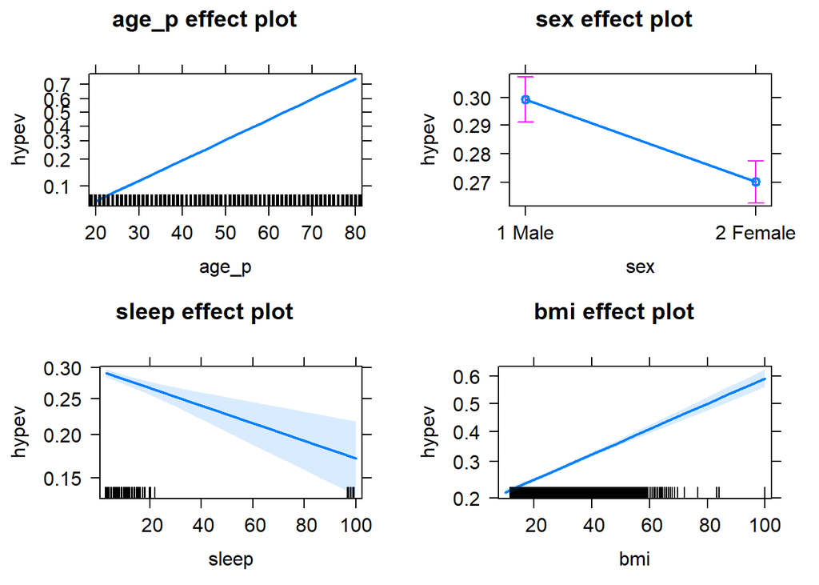

## Comparing Models

Useing the NH11 data set, I will use glm to conduct a logistic regression to predict ever worked (everwrk) using age (age_p) and marital status (r_maritl). Then Predict the probability of working for each level of marital status.

```
##  Factor w/ 5 levels "1 Yes","2 No",..: NA NA 1 NA NA NA NA NA 1 1 ...
```

```
## [1] "1 Yes"             "2 No"              "7 Refused"
## [4] "8 Not ascertained" "9 Don't know"
```

```
##                                                Estimate  Std. Error
## (Intercept)                                 -0.45415880 0.093080415
## age_p                                       -0.02934571 0.001633363
## r_maritl2 Married - spouse not in household  0.08145957 0.213835768
## r_maritl4 Widowed                            0.68688235 0.083623142
## r_maritl5 Divorced                          -0.73211254 0.111144918
## r_maritl6 Separated                         -0.11644701 0.150189947
## r_maritl7 Never married                      0.35522972 0.068864919
## r_maritl8 Living with partner               -0.44622604 0.137653720
## r_maritl9 Unknown marital status             0.54103849 0.457837543
##                                                 z value     Pr(>|z|)
## (Intercept)                                  -4.8792091 1.065121e-06
## age_p                                       -17.9664355 3.569242e-72
## r_maritl2 Married - spouse not in household   0.3809446 7.032444e-01
## r_maritl4 Widowed                             8.2140223 2.138998e-16
## r_maritl5 Divorced                           -6.5870087 4.487759e-11
## r_maritl6 Separated                          -0.7753316 4.381438e-01
## r_maritl7 Never married                       5.1583553 2.491285e-07
## r_maritl8 Living with partner                -3.2416562 1.188373e-03
## r_maritl9 Unknown marital status              1.1817259 2.373145e-01
```

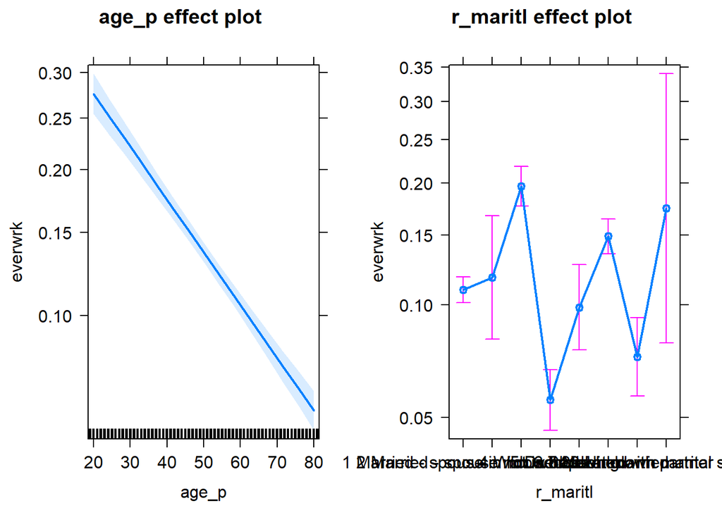